# Data1 Analysis

wudayu PB19030934

12/16/2021

## Read data1

```r
data1<-read.csv("~/Desktop/data1.csv")
head(data1,10)
```

```
##                TIME     LONG      LAT CONSUM LONGACC  SPEED   WHEEL CUMDIS
## 1  2016/11/11 19:50 122.0951 40.20291    6.1   -0.22 37.875 1505.00   3127
## 2  2016/11/11 19:50 122.0951 40.20291    6.6   -0.32 38.400 1534.50   3127
## 3  2016/11/11 19:50 122.0951 40.20291    5.6   -0.32 38.625 1532.75   3127
## 4  2016/11/11 19:50 122.0951 40.20291    5.0   -0.98 37.425 1485.50   3127
## 5  2016/11/11 19:50 122.0951 40.20291    3.0   -0.88 36.075 1426.25   3127
## 6  2016/11/11 19:50 122.0951 40.20291    0.8   -0.78 34.575 1374.75   3127
## 7  2016/11/11 19:50 122.0951 40.20291    0.8   -0.78 34.575 1374.75   3127
## 8  2016/11/11 19:50 122.0951 40.20291    0.5   -0.58 33.750 1345.75   3127
## 9  2016/11/11 19:50 122.0951 40.20291    3.0   -0.44 32.850 1309.00   3127
## 10 2016/11/11 19:50 122.0951 40.20291    3.5   -0.58 32.400 1288.75   3127
```

## Trail

It starts at (122.0951, 40.20291) and goes northwestern reaching (122.0711, 40.21057) before gets back.

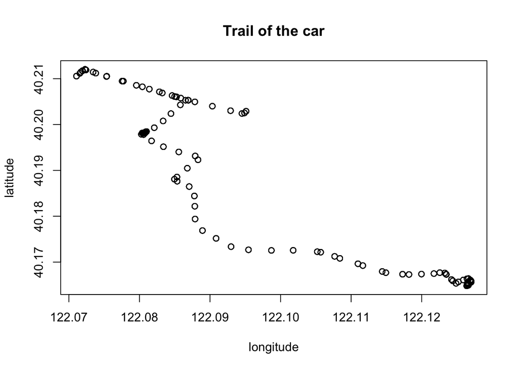

```r
longitude<-data1$LONG
latitude<-data1$LAT
plot(x=longitude,y=latitude,title("Trail of the car"))
```

## Descriptive Statistics

```r
summary(data1)
```

```
##      TIME                LONG            LAT            CONSUM
##  Length:1575        Min.   :122.1   Min.   :40.16   Min.   : 0.000
##  Class :character   1st Qu.:122.1   1st Qu.:40.17   1st Qu.: 2.400
##  Mode  :character   Median :122.1   Median :40.19   Median : 6.400
##                     Mean   :122.1   Mean   :40.19   Mean   : 7.564
##                     3rd Qu.:122.1   3rd Qu.:40.21   3rd Qu.:11.300
##                     Max.   :122.1   Max.   :40.21   Max.   :20.000
##     LONGACC            SPEED            WHEEL            CUMDIS
##  Min.   :-8.6600   Min.   : 0.000   Min.   : 657.5   Min.   :3127
##  1st Qu.:-0.6200   1st Qu.: 8.925   1st Qu.: 947.5   1st Qu.:3129
##  Median :-0.4200   Median :32.175   Median :1401.5   Median :3133
##  Mean   :-0.4224   Mean   :32.740   Mean   :1354.2   Mean   :3134
##  3rd Qu.:-0.1400   3rd Qu.:54.375   3rd Qu.:1669.4   3rd Qu.:3139
##  Max.   : 1.6400   Max.   :86.625   Max.   :2650.0   Max.   :3141
```

## Distributions of numerics

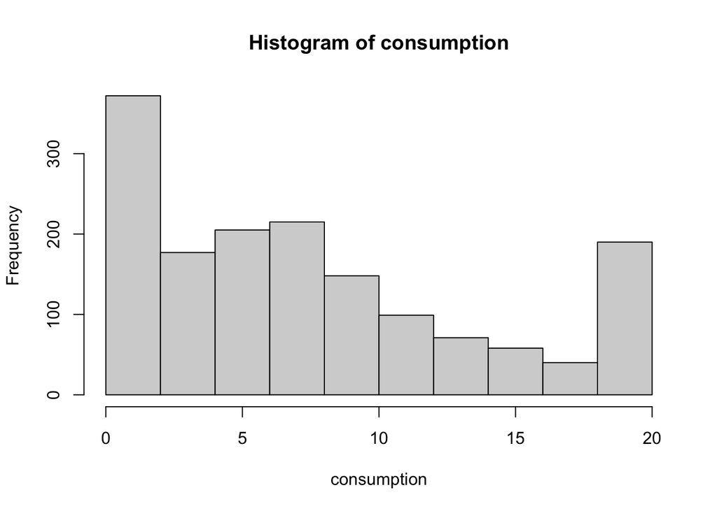

```r
consumption<-data1$CONSUM
acceleration<-data1$LONGACC
speed<-data1$SPEED
wheel<-data1$WHEEL
distance<-data1$CUMDIS
hist(consumption, main = paste("Histogram of consumption"))
```

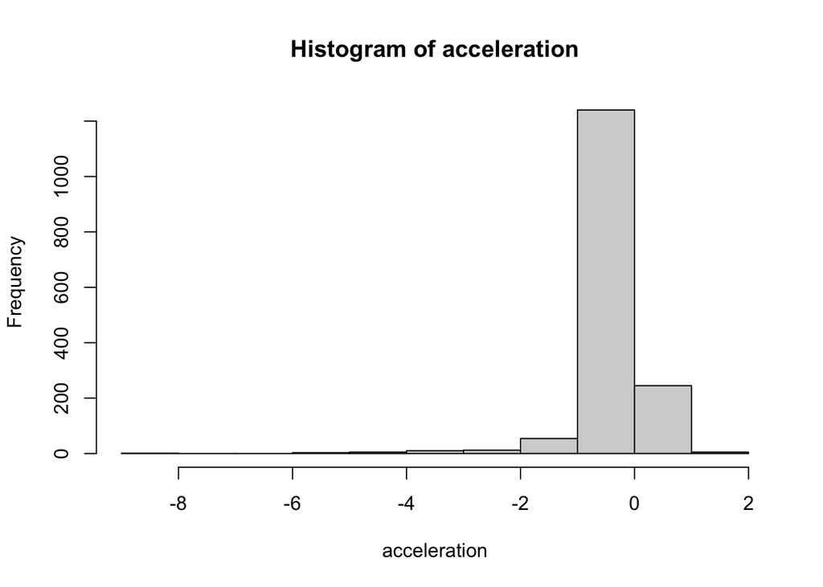

```r
hist(acceleration, main = paste("Histogram of acceleration"))
```

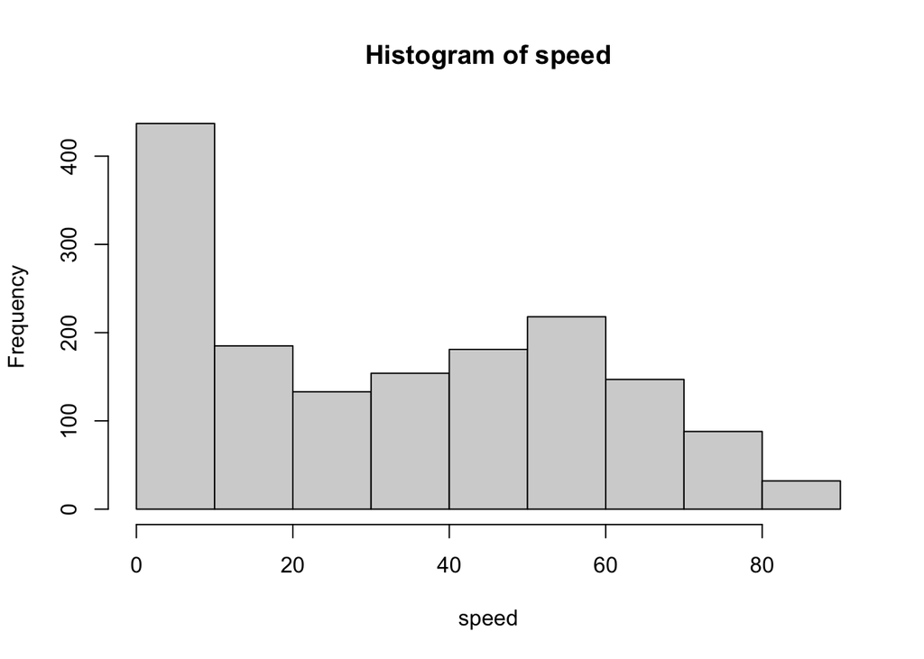

```r
hist(speed, main = paste("Histogram of speed"))
```

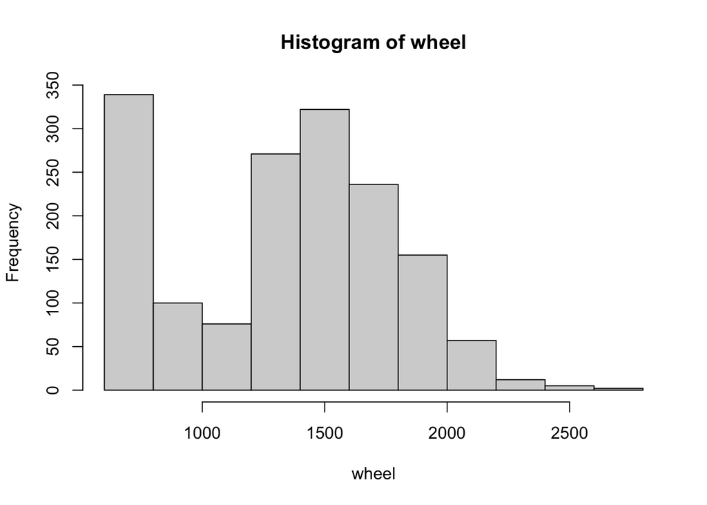

```r
hist(wheel, main = paste("Histogram of wheel"))
```

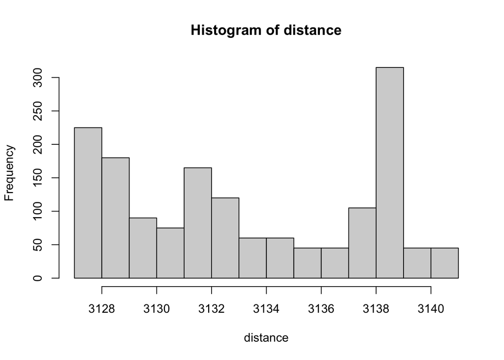

```r
hist(distance, main = paste("Histogram of distance"))
```

## Explanation of histogram

1. Firstly, note that if we ignore the relatively small data (first bar in each histogram) in CONSUM, SPEED and WHEEL, it seems we’ll have a more norm like distribution. This implies that sometimes the driving speed is low while in other times the speed has a norm-like distribution. It could be easily explained if we consider this scenario, at crosses and turnings, the speed slows down to a level. And if we don’t consider these slowing down, the speed behaves like many other variables largely holding a norm distribution.
2. The Histogram of distance seems quite abnormal because that if we have a continuous stable record of one certain car, then it would seem like a uniform distribution.

However, since data is collected on a 15 seconds basis, the more one certain number occurred in cumulative distance, the longer the driver stayed in that road section, which leads to a low average speed in that place.

Then we may conclude that the driver followed such a driving history:

At the beginning, the car might be around certain district that only allows low speed driving, such as business circle, busy main road, etc.

Then the car sped up till entered another district with limitation.

After that the car might get on the highway and keep going with a relatively high speed.

Suddenly, it got stuck at around distance 3138 for a long time, which might be an accidence.

Finally, it continue to go.

## Correlation

```r
M<-cor(data1[-1])
M
```

```
##                LONG         LAT     CONSUM     LONGACC       SPEED       WHEEL
## LONG     1.00000000 -0.91959466  0.1627163 -0.02702094 -0.07583809 -0.02878680
## LAT     -0.91959466  1.00000000 -0.1181992  0.02487104 -0.09154762 -0.06391458
## CONSUM   0.16271633 -0.11819923  1.0000000  0.41445050 -0.27464598  0.14643172
## LONGACC -0.02702094  0.02487104  0.4144505  1.00000000  0.07064817  0.32120163
## SPEED   -0.07583809 -0.09154762 -0.2746460  0.07064817  1.00000000  0.71749350
## WHEEL   -0.02878680 -0.06391458  0.1464317  0.32120163  0.71749350  1.00000000
## CUMDIS   0.86808143 -0.95571116  0.1077370 -0.03942410  0.08658838  0.06109512
##              CUMDIS
## LONG     0.86808143
## LAT     -0.95571116
## CONSUM   0.10773695
## LONGACC -0.03942410
## SPEED    0.08658838
## WHEEL    0.06109512
## CUMDIS   1.00000000
```

```r
library(Hmisc)
rcorr(as.matrix(data1[-1]))
```

```
##          LONG   LAT CONSUM LONGACC SPEED WHEEL CUMDIS
## LONG     1.00 -0.92   0.16   -0.03 -0.08 -0.03   0.87
## LAT     -0.92  1.00  -0.12    0.02 -0.09 -0.06  -0.96
## CONSUM   0.16 -0.12   1.00    0.41 -0.27  0.15   0.11
## LONGACC -0.03  0.02   0.41    1.00  0.07  0.32  -0.04
## SPEED   -0.08 -0.09  -0.27    0.07  1.00  0.72   0.09
## WHEEL   -0.03 -0.06   0.15    0.32  0.72  1.00   0.06
## CUMDIS   0.87 -0.96   0.11   -0.04  0.09  0.06   1.00
##
## n= 1575
##
##
## P
##         LONG   LAT    CONSUM LONGACC SPEED  WHEEL  CUMDIS
## LONG           0.0000 0.0000 0.2839  0.0026 0.2535 0.0000
## LAT     0.0000        0.0000 0.3239  0.0003 0.0112 0.0000
## CONSUM  0.0000 0.0000        0.0000  0.0000 0.0000 0.0000
## LONGACC 0.2839 0.3239 0.0000         0.0050 0.0000 0.1178
## SPEED   0.0026 0.0003 0.0000 0.0050         0.0000 0.0006
## WHEEL   0.2535 0.0112 0.0000 0.0000  0.0000        0.0153
## CUMDIS  0.0000 0.0000 0.0000 0.1178  0.0006 0.0153
```

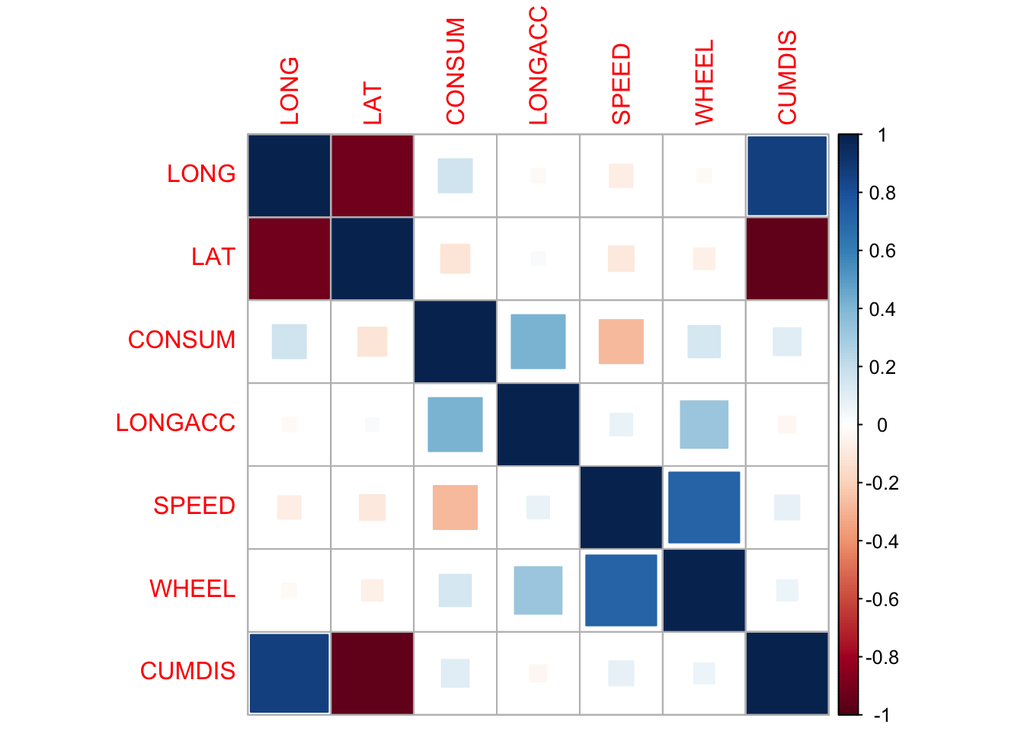

```r
library(corrplot)
corrplot(method="square",M)
```

1. Clearly, distance, longitude and latitude are all closely related. Since the car goes largely towards southeast, distance certainly would have separately a positive and negative relationship with longitude and latitude.
2. Note that consumption is closely related with acceleration and speed, while acceleration is related with wheel.
3. Taking the road condition into consideration, speed and consumption have something to do with longitude and latitude.
4. It’s interesting to find that speed and wheel are closely related.

## Stationarity Analysis

When it comes to the driving behavior, stationary is most important thing we would consider first.

To picture the stationary of this drive, we ought to analysis variable speed using timeseries techniques.

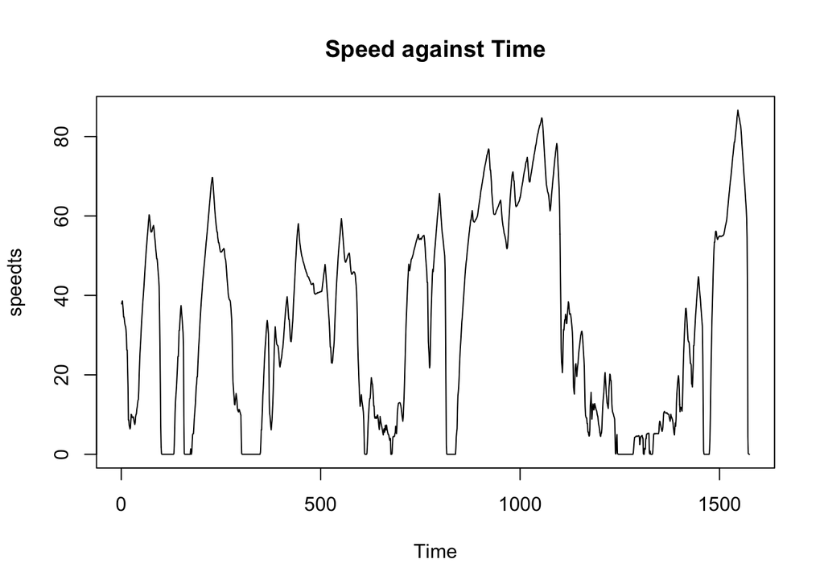

```r
speedts<-ts(speed, start=1, end=1575)
plot(speedts,type='l',main='Speed against Time')
```

```r
library(forecast)
```

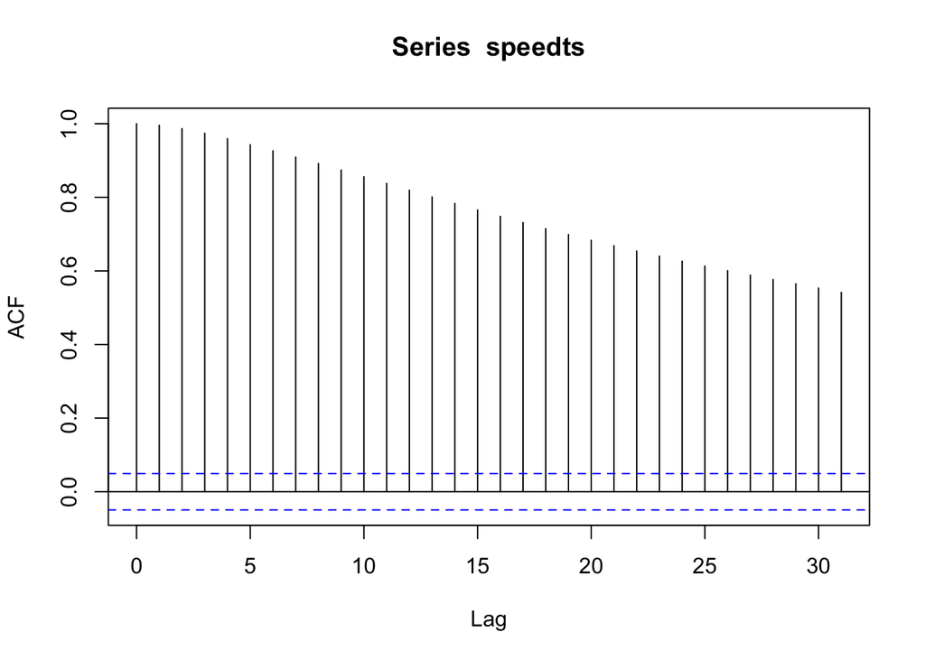

```r
library(tseries)
acf(speedts)
```

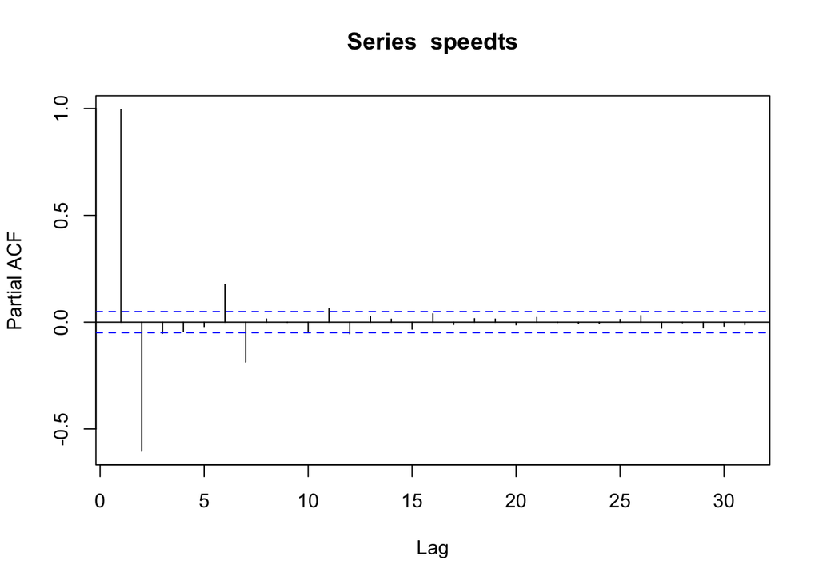

```r
pacf(speedts)
```

```r
Box.test(speedts,type = "Ljung-Box")
```

```
##
##  Box-Ljung test
##
## data:  speedts
## X-squared = 1564.8, df = 1, p-value < 2.2e-16
```

```r
ndiffs(speedts)
```

```
## [1] 1
```

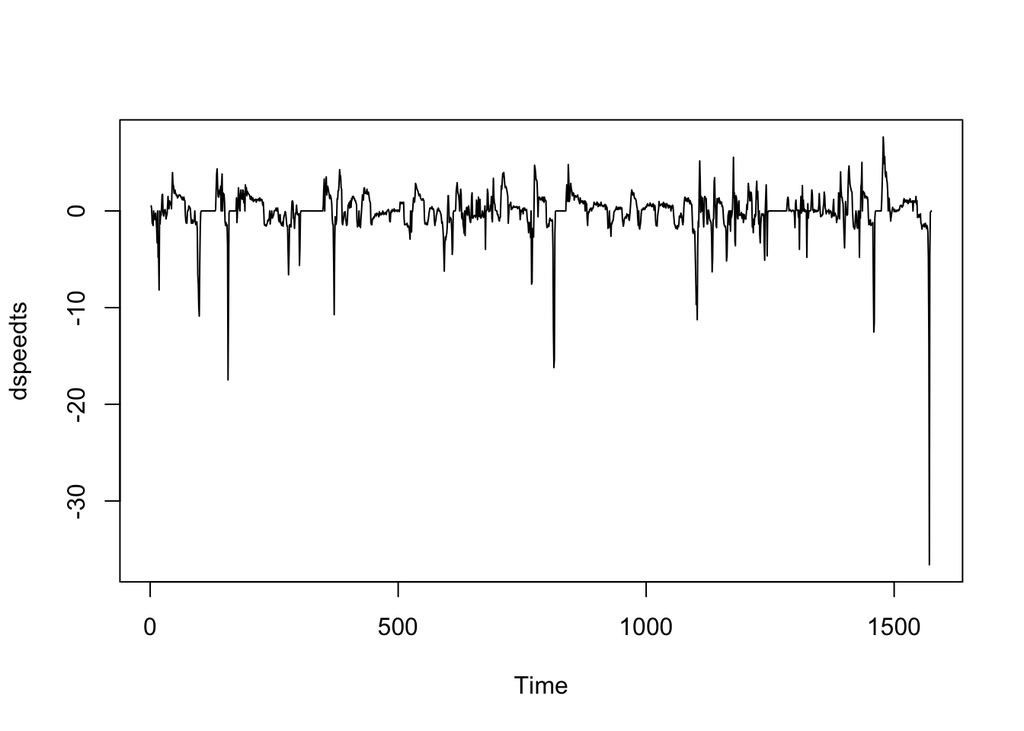

```r
dspeedts <- diff(speedts)
plot(dspeedts)
```

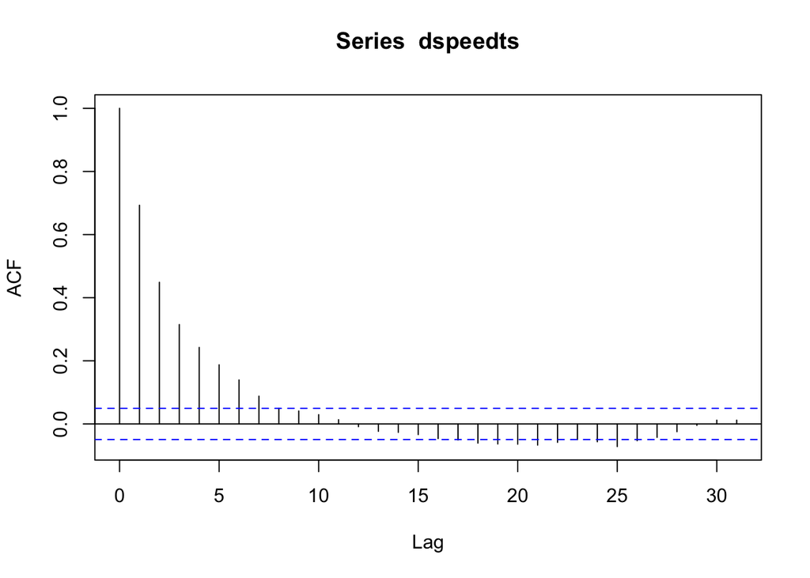

```r
acf(dspeedts)
```

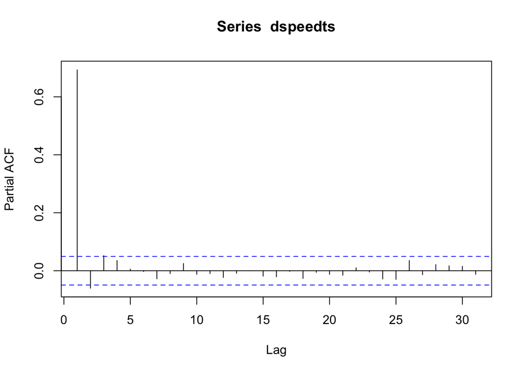

```r
pacf(dspeedts)
```

```r
Box.test(dspeedts,type = "Ljung-Box")
```

```
##
##  Box-Ljung test
##
## data:  dspeedts
## X-squared = 757.22, df = 1, p-value < 2.2e-16
```

From the ACF and PACF graph, we find that ARIMA(1,1,3) is what we need for speedts.

To double check this result, we then apply auto.arima to this data and the results support our conclusion above.

```r
fit.speed<-auto.arima(speedts)
summary(fit.speed)
```

```
## Series: speedts
## ARIMA(1,1,3)
##
## Coefficients:
##          ar1      ma1      ma2      ma3
##       0.7588  -0.0229  -0.1112  -0.0517
## s.e.  0.0487   0.0555   0.0453   0.0338
##
## sigma^2 estimated as 2.344:  log likelihood=-2902.22
## AIC=5814.44   AICc=5814.48   BIC=5841.25
##
## Training set error measures:
##                        ME     RMSE       MAE MPE MAPE     MASE         ACF1
## Training set -0.007508292 1.528646 0.6970792 NaN  Inf 0.603746 0.0001889673
```

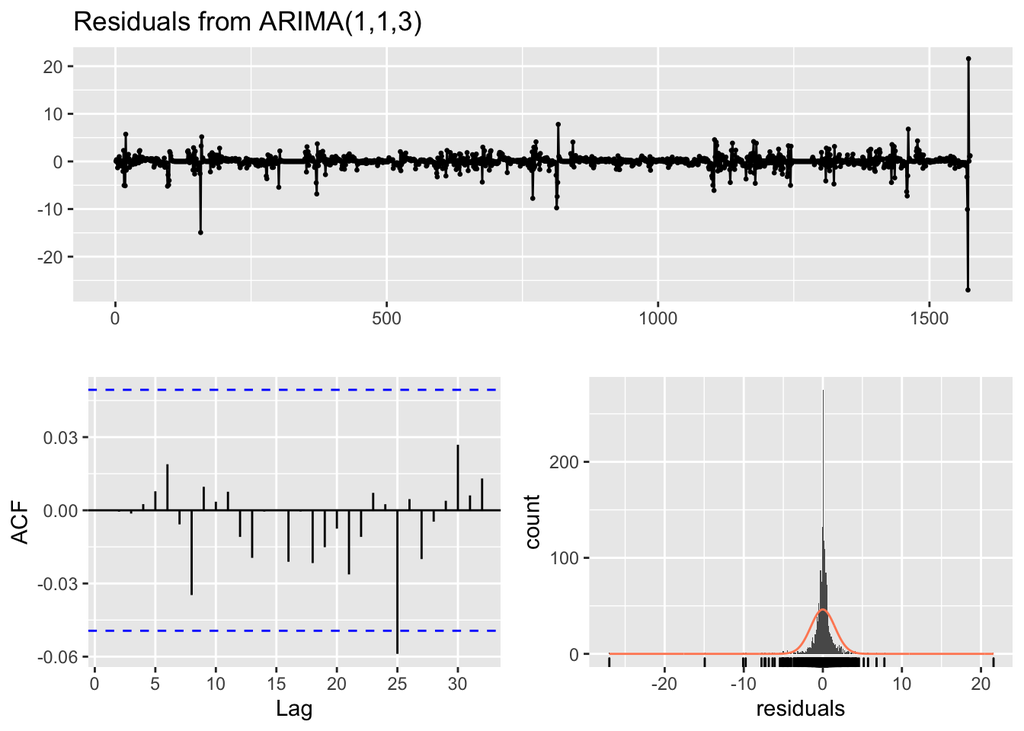

```
##
##  Ljung-Box test
##
## data:  Residuals from ARIMA(1,1,3)
## Q* = 2.8065, df = 6, p-value = 0.8327
##
## Model df: 4.   Total lags used: 10
```

```r
checkresiduals(fit.speed)
```

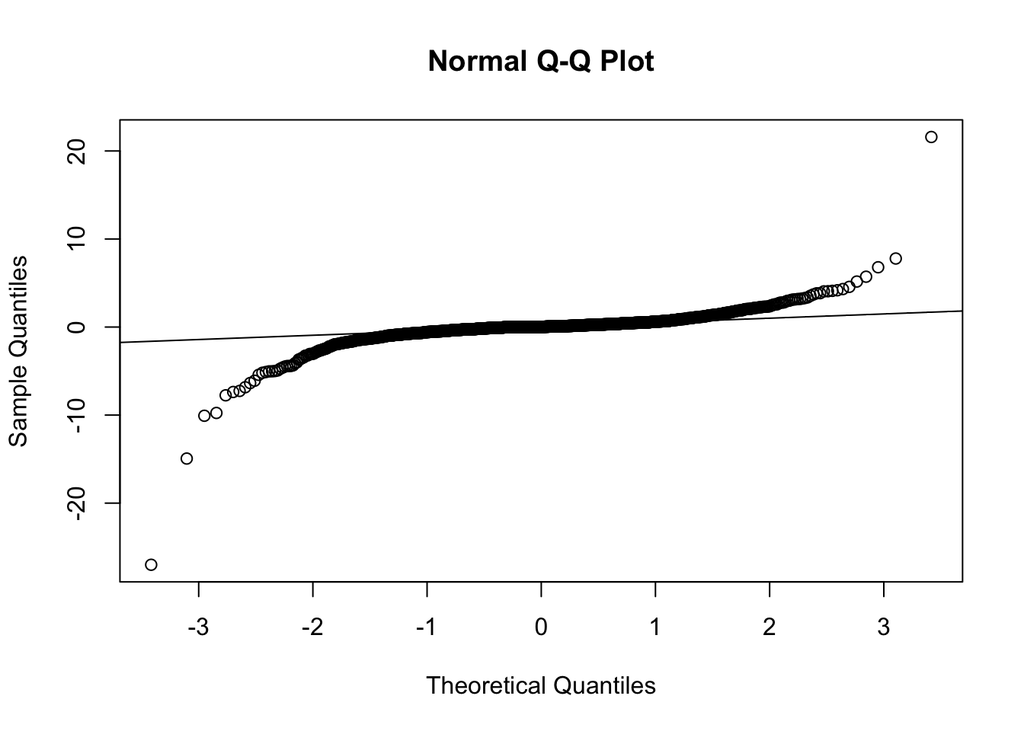

```r
qqnorm(fit.speed$residuals)
qqline(fit.speed$residuals)
```

As the model settled down, some simple predictions are made as below.

```r
forecast(fit.speed,10,level=c(99.5))
```

```
##      Point Forecast    Lo 99.5   Hi 99.5
## 1576     -0.1472180  -4.445005  4.150569
## 1577     -0.4469154  -9.056498  8.162668
## 1578     -0.7365776 -13.469942 11.996787
## 1579     -0.9563593 -17.535369 15.622651
## 1580     -1.1231190 -21.331430 19.085192
## 1581     -1.2496483 -24.889306 22.390009
## 1582     -1.3456527 -28.231032 25.539727
## 1583     -1.4184962 -31.376308 28.539315
## 1584     -1.4737663 -34.343614 31.396081
## 1585     -1.5157026 -37.150195 34.118790
```

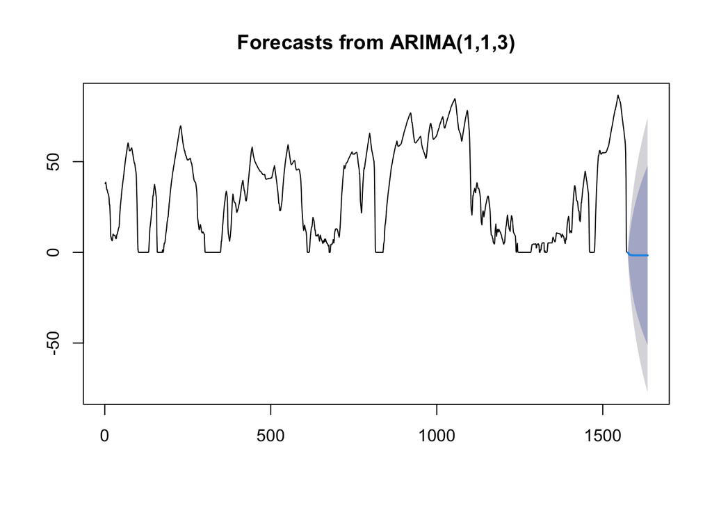

```r
plot(forecast(fit.speed,60))
```

Well, it seems that the party is over and no one would be on the raod :)

## Stationary Analysis 2

Apart from stationary of speed we get as above , LONGACC is a similar index for stationary of machine.

We wonder whether these two characters will behave similarly. Or namely, ARIMZ(1,0,3) for LONGACC?

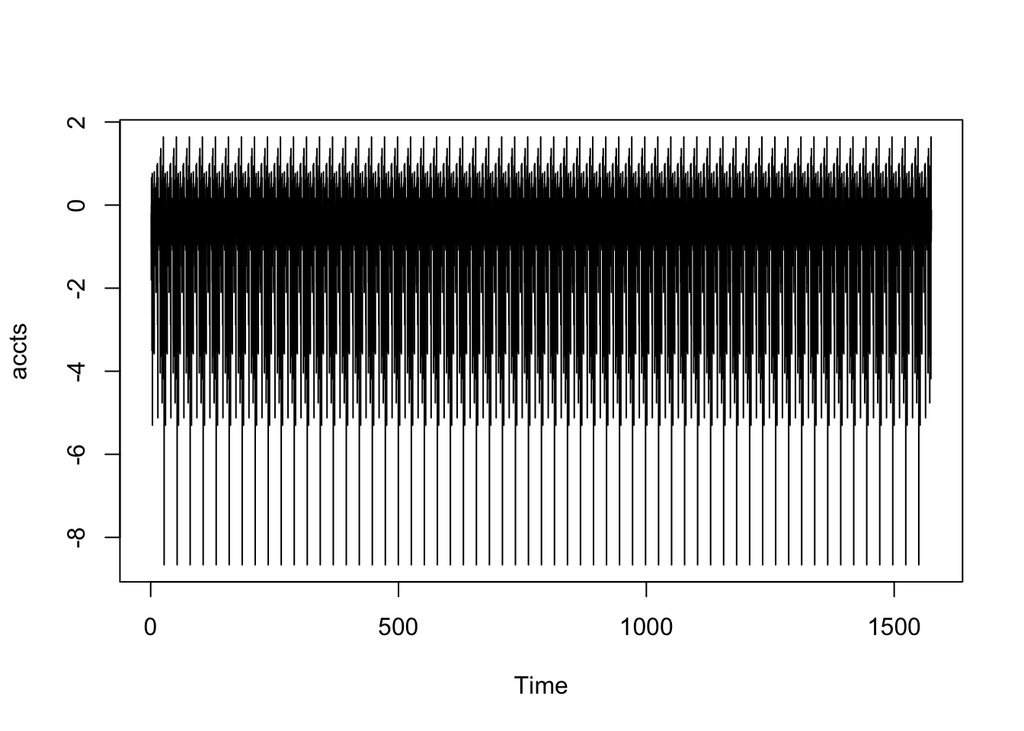

```r
accts<-ts(acceleration,start=1,end=1575,frequency = 60)
plot(accts)
```

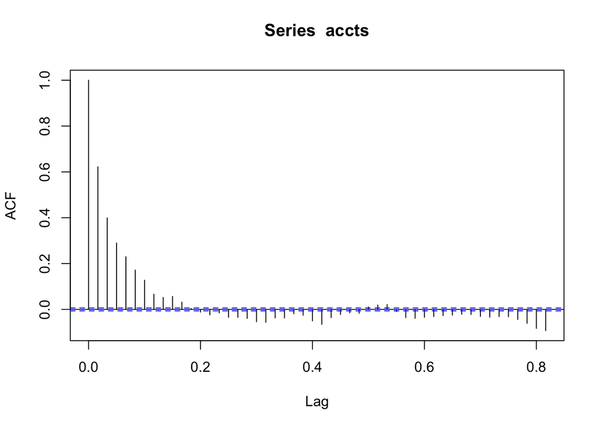

```r
acf(accts)
```

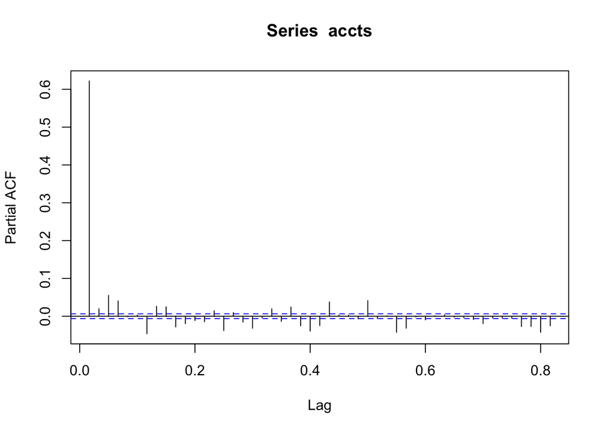

```r
pacf(accts)
```

```r
Box.test(accts,type = "Ljung-Box")
```

```
##
##  Box-Ljung test
##
## data:  accts
## X-squared = 36547, df = 1, p-value < 2.2e-16
```

```r
ndiffs(accts)
```

```
## [1] 0
```

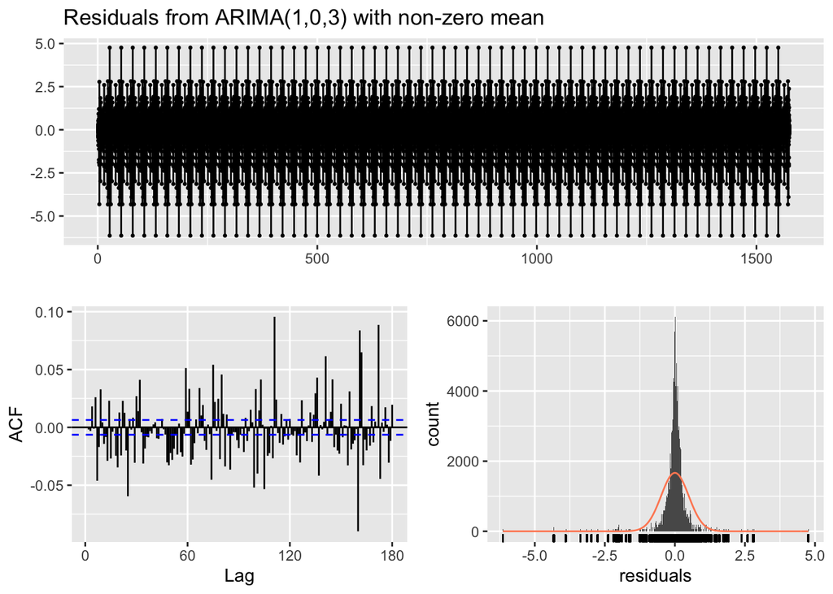

```
##
##  Ljung-Box test
##
## data:  Residuals from ARIMA(1,0,3) with non-zero mean
## Q* = 6507.4, df = 115, p-value < 2.2e-16
##
## Model df: 5.   Total lags used: 120
```

```r
fit.accts<-arima(accts,order=c(1,0,3))
checkresiduals(fit.accts)
```

The ACF graph shows that ARIMA(1,0,3) is not suitable for acceleration.

This implies that acceleration get form sensor do not coordinate with acceleration get from speed.

BUT WHY?

We think that LONGACC may be a acceleration along longitude thus shows a regular pattern and do not fit ARIMA model constructed on speed.

## Consumption Model

Consumption is very important for both driver and supplier.

From the correlation matrix and significance, we note that all factors are significantly (linearly) related with CONSUM.

Thus we now consider to predict CONSUM with other factors.

Since in this data set, outliers would greatly influence the performance of OLS and we apply ridge regression here.

```r
library(glmnet)
y<-scale(consumption)
x<-as.matrix(cbind(scale(longitude),scale(latitude),scale(speed),scale(wheel),scale(acceleration),scale(distance)))
model <- glmnet(x, y, alpha = 0)
cv_model <- cv.glmnet(x, y, alpha = 0)
best_lambda <- cv_model$lambda.min
best_lambda
```

```
## [1] 0.04143189
```

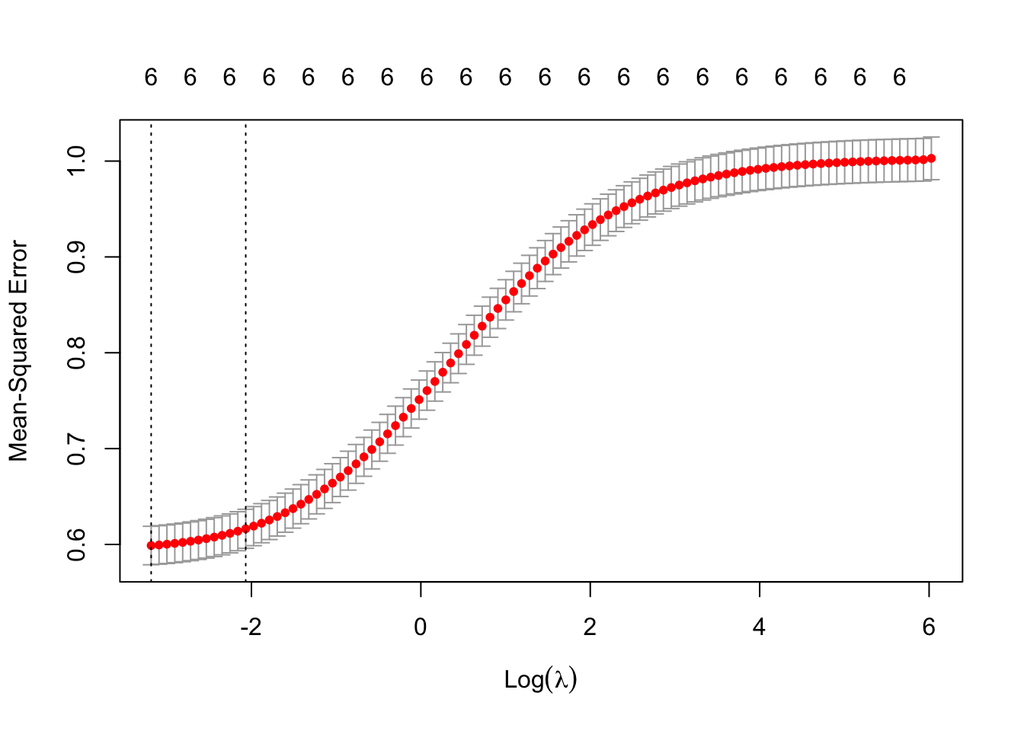

```r
plot(cv_model)
```

```r
best_model <- glmnet(x, y, alpha = 0, lambda = best_lambda)
coef(best_model)
```

```
## 7 x 1 sparse Matrix of class "dgCMatrix"
##                        s0
## (Intercept) -1.405034e-14
## V1           1.086471e-02
## V2          -1.126621e-01
## V3          -6.143130e-01
## V4           4.629003e-01
## V5           3.008257e-01
## V6           2.631371e-02
```

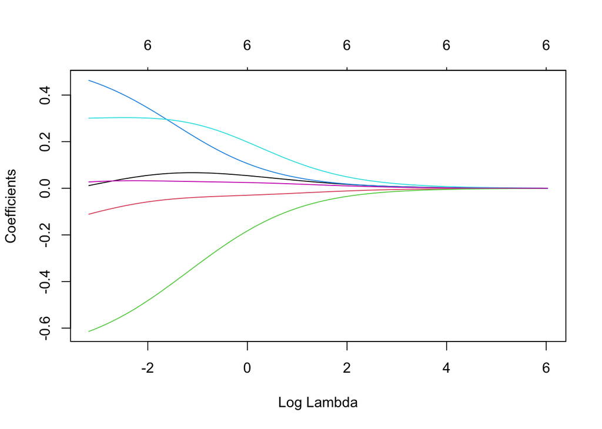

```r
plot(model, xvar = "lambda")
```

With this model we may help to predict consumption of cars around this area, which would certainly be beneficial for local gas stations.

## Other things we may include in driving behavior

One thing should be mention: the number of sudden acceleration.

If a driver undergoes to many sudden accelerations, then the road condition can’t be very good or the driver can’t be very skillful.

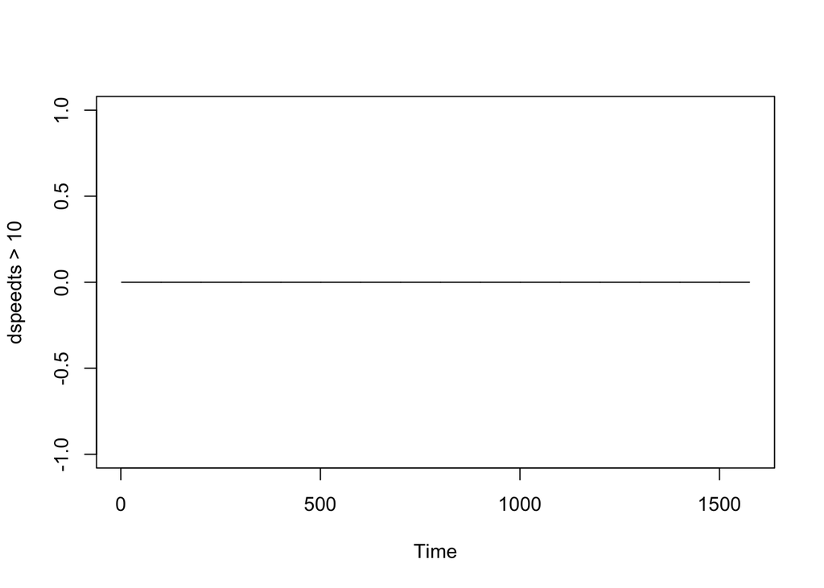

```r
plot(dspeedts>10)
```

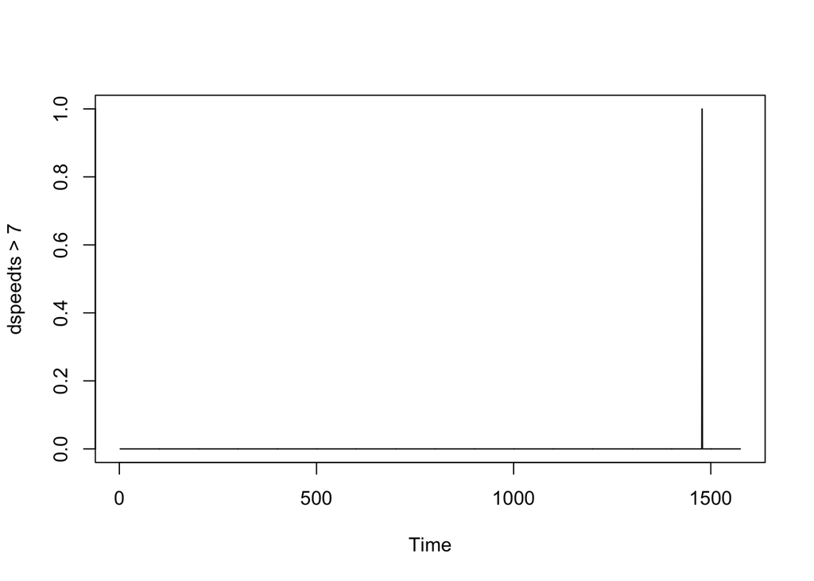

```r
plot(dspeedts>7)
```

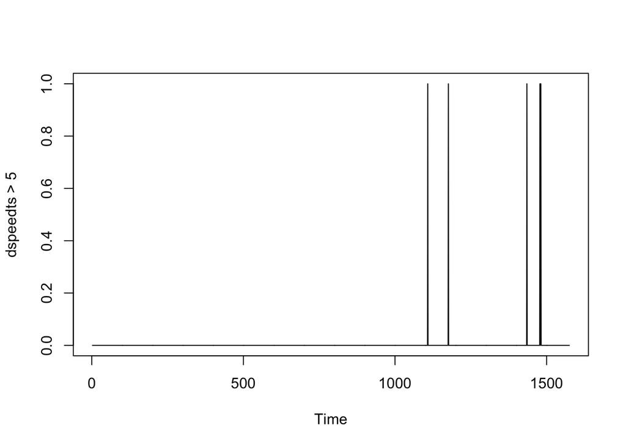

```r
plot(dspeedts>5)
```

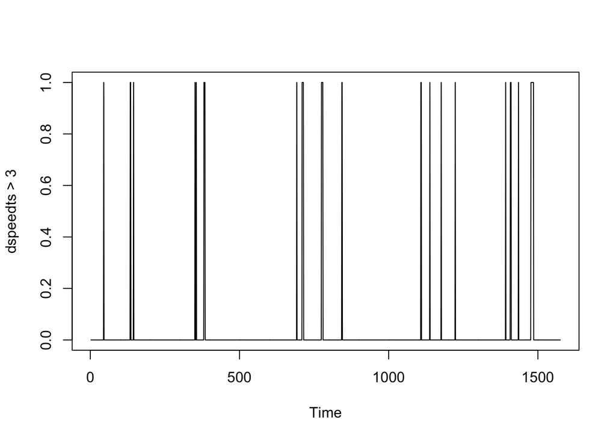

```r
plot(dspeedts>3)
```

Driver Variability

Another way to show stability is to plot(speed(t),speed(t+1)).

Dots below the diagnose are outliers with relatively significant change of speed.

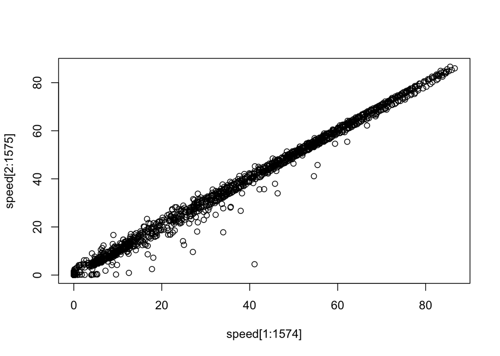

```r
plot(x=speed[1:1574],y=speed[2:1575])
```

## To Be Continued

To better value and test our models, we then apply and develop them in data2